# Analysis example with the NICU dataset

Guilherme Marcelino Viana de Siqueira, Felipe Marcelo Pereira-dos-Santos, Rafael Silva-Rocha and María-Eugenia Guazzaroni

July 21<sup>st</sup>, 2021

# Introduction

In this document, we illustrate some of the steps taken in our work [Nanopore sequencing provides rapid and reliable insight into microbial profiles of Intensive Care Units](https://www.frontiersin.org/articles/10.3389/fpubh.2021.710985/abstract), in which we compared the microbial composition of hospital surfaces using two distinct sequencing approaches (2<sup>nd</sup> generation short-read Illumina sequencing and 3<sup>rd</sup> generation long-read Nanopore sequencing). In this working example, we will compare results for the Neonatal ICU (NICU) microbiota and compare whether there were significative differences between the two approaches.

# Analysis

### Importing the needed packages

```r
library(tidyr)
library(readr)
library(tibble)
library(magrittr)
library(vegan)
library(dplyr)
library(ggplot2)
library(reshape2)
library(dendextend)
library(ggtext)
library(stringr)
library(purrr)
library(forcats)
library(RColorBrewer)
```

### Input data

We have provided two tables (minION_nicu.tsv and illumina_nicu.tsv) in this directory with relative abundances for the taxa detected in both sequencing approaches. In short, OTU / read count tables were obtained at the end of each analysis pipeline (QIIME or our custom nanopore pipeline) and abundance values were normalized using the total sum scaling (TSS) method, that is, the value of each individual group was divided by the total of each sample to generate a table of relative frequencies.

We may import these tables in the following objects `minION_nicu` and `illumina_nicu` before continuing the analysis

```r
# reading the data frames from the files
minION_nicu <- read_tsv("minION_nicu.tsv")
illumina_nicu <- read_tsv("illumina_nicu.tsv")
# checking the result out
head(minION_nicu)[,1:4] #just checking the first few columns and rows
```

```
## # A tibble: 6 x 4
##   taxa            `Pump-NICUa` `Mattress-NICUa` `Rail-NICUa`
##   <chr>                  <dbl>            <dbl>        <dbl>
## 1 Abiotrophia          0                      0            0
## 2 Acidovorax           0.00179                0            0
## 3 Acinetobacter        0.00434                0            0
## 4 Aerococcus           0                      0            0
## 5 Aeromonas            0                      0            0
## 6 Aggregatibacter      0                      0            0
```

```r
head(illumina_nicu)[,1:4] #just checking the first few columns and rows
```

```
## # A tibble: 6 x 4
##   taxa            `Pump-NICUa` `Mattress-NICUa` `Rail-NICUa`
##   <chr>                  <dbl>            <dbl>        <dbl>
## 1 Acholeplasma         0                0          0
## 2 Acidaminococcus      0                0          0
## 3 Acidisoma            0                0          0.0000872
## 4 Aciditerrimonas      0                0          0
## 5 Acidovorax           0.00523          0.00369    0.00863
## 6 Acinetobacter        0.0146           0.00805    0.00616
```

As we might notice, both data frames contain a column with the name of the different genera detected (“taxa”) and several columns with their relative abundance values. In some of the steps that follow we would rather have these data frames as *matrices* (i.e. all numeric). We are going to do it by turning the first column in each of them to the row names

```r
minION_nicu_mat  <- minION_nicu %>% column_to_rownames(var = "taxa")
illumina_nicu_mat <- illumina_nicu %>% column_to_rownames(var = "taxa")
head(minION_nicu_mat)[,1:4] #just checking the first few columns and rows
```

```
##                  Pump-NICUa Mattress-NICUa Rail-NICUa Monitor-NICUa
## Abiotrophia     0.000000000              0          0   0.003638569
## Acidovorax      0.001787995              0          0   0.000000000
## Acinetobacter   0.004342273              0          0   0.013038205
## Aerococcus      0.000000000              0          0   0.000000000
## Aeromonas       0.000000000              0          0   0.000000000
## Aggregatibacter 0.000000000              0          0   0.000000000
```

```r
head(illumina_nicu_mat)[,1:4] #just checking the first few columns and rows
```

```
##                  Pump-NICUa Mattress-NICUa   Rail-NICUa Monitor-NICUa
## Acholeplasma    0.000000000    0.000000000 0.0000000000  0.0000000000
## Acidaminococcus 0.000000000    0.000000000 0.0000000000  0.0000000000
## Acidisoma       0.000000000    0.000000000 0.0000872017  0.0000000000
## Aciditerrimonas 0.000000000    0.000000000 0.0000000000  0.0000872017
## Acidovorax      0.005232102    0.003691539 0.0086329681  0.0018893701
## Acinetobacter   0.014620818    0.008051623 0.0061622533  0.0383687469
```

We may now proceed to different analyses.

### Calculating diversity indexes

In R, the [package vegan](https://cran.r-project.org/web/packages/vegan/index.html) provides several utilities for researchers working with community ecology. The function `diversity()` allows us to calculate Shannon’s diversity index (and several others) starting from our matrices. In the function calls below, the argument `MARGIN = 2` allows us to compute the indexes column-wise, since that’s the way our data is organized.

```r
minION_nicu_div <- diversity(minION_nicu_mat, index = "shannon", MARGIN = 2)
illumina_nicu_div <- diversity(illumina_nicu_mat, index = "shannon", MARGIN = 2)
head(minION_nicu_div)
```

```
##       Pump-NICUa   Mattress-NICUa       Rail-NICUa    Monitor-NICUa
##         1.700259         1.197346         1.337446         2.527351
## Ventilator-NICUa       Pump-NICUb
##         1.942890         1.577005
```

```r
head(illumina_nicu_div)
```

```
##       Pump-NICUa   Mattress-NICUa       Rail-NICUa    Monitor-NICUa
##         2.960103         1.719606         2.239593         3.098485
## Ventilator-NICUa       Pump-NICUb
##         2.826911         3.410361
```

The output of vegan’s diversity function is a named vector with the computed values for each of our samples. While it is already possible to interpret data like this, we may wish to process it further to better visualize the data. The code chunk below prepares data for ggplot plotting.

```r
### making data longer for ggplot2
# First, for the minION dataset
minION_nicu_div %<>% melt(value.name = "index") %>%
  rownames_to_column(var = "samples") %>% # creates a new column with the row names
  mutate(method = "minION", ward = "NICU") # creates new columns for the sequencing method and ward the samples were collected in
# Now for the illumina dataset, same as above.
illumina_nicu_div %<>% melt(value.name = "index") %>%
  rownames_to_column(var = "samples") %>%
  mutate(method = "Illumina", ward = "NICU")
## joining the tables
diversity_nicu <- bind_rows(minION_nicu_div, illumina_nicu_div)
```

We might now proceed to generating our heat map

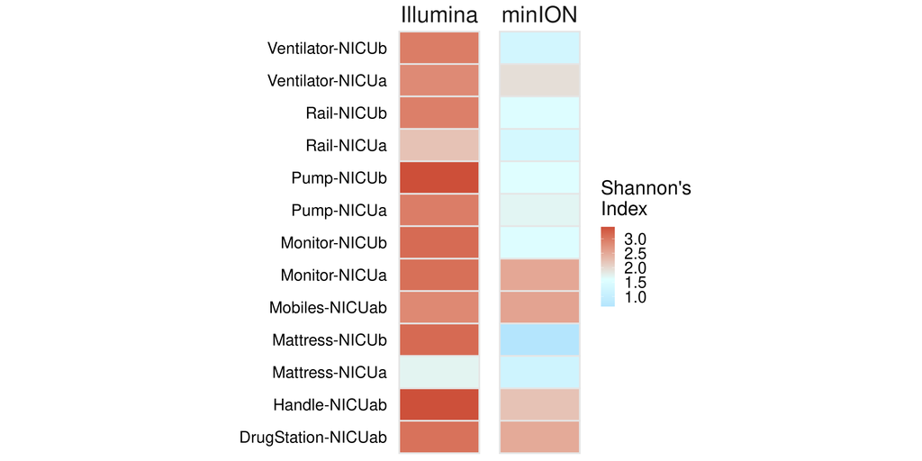

```r
ggplot(diversity_nicu, aes(y = samples, x = ward, fill = index)) +
  geom_tile(color = "gray90", size = 1) +
  facet_wrap(~ method) + labs(y = "", x = "", fill = "Shannon's\nIndex") +
  scale_fill_gradient2(low = "lightskyblue",
                       high = "tomato3",
                       mid = "lightcyan1",
                       midpoint = 1.6) +
  theme( # personalization of axis text

        axis.title.x = element_blank(),
        axis.text.x = element_blank(),
        axis.text = element_text(size = 20, color = "black"),
        axis.ticks = element_blank(),
        # personalization of the legend
        legend.title = element_text(size = 24),
        legend.text = element_text(size = 20),
        legend.key.height = unit(20, units = "pt"),

        # personalization of the panels
        panel.background = element_rect(fill = "white"),
        strip.background = element_rect(fill = "white"),
        strip.text = element_text(size = 28),

        # aspect ratio of the panel and margins of the plot
        plot.margin = margin(t = 0, l = 3, r = 0, b = 3),
        aspect.ratio = 49/11)
```

As discussed in the manuscript, we can see that diversity values were lower with nanopore sequencing than with illumina sequencing. We see this as an direct consequence of the limitations in throughput obtained with nanopore sequencing due to the use of Flongle flowcells. Next, we may evaluate whether these differences impact the analysis as a whole.

### Comparing dendrograms

While the information of the diversity indexes may help us appreciate differences in richness between samples, we would also like to understand how differently the samples relate to one another in both methods. The [package dendextend](https://cran.r-project.org/web/packages/dendextend/index.html) allows us to draw dendrograms and compare them side-by-side with tanglegrams. Moreover, it makes it possible to compute the cophenetic correlation index between the dendrograms and other useful metric that we may include in our figures.

The code chunk below demonstrates how to generate a tanglegram starting from our matrices

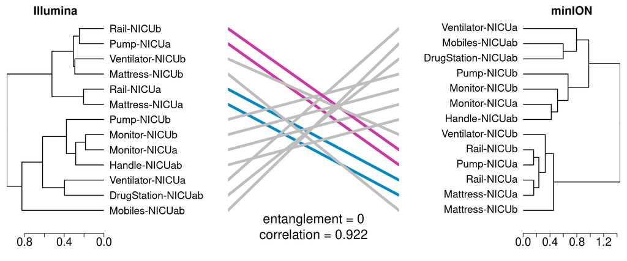

```r
# Let's calculate the dissimilarity matrices between the samples individually for each sequencing method. Here, we use the Bray-Curtis method
NICU_minION_d <- vegan::vegdist(x = t(minION_nicu_mat), method = "bray")
NICU_illumina_d <- vegan::vegdist(x = t(illumina_nicu_mat), method = "bray")
# Next, we compute both hierarchical clusterings with the function hclust
NICU_minION_hc <- hclust(NICU_minION_d, method = "ward.D2")
NICU_illumina_hc <- hclust(NICU_illumina_d, method = "ward.D2")
# Create the two dendrograms
NICU_dend1 <- as.dendrogram(NICU_illumina_hc)
NICU_dend2 <- as.dendrogram(NICU_minION_hc)
# Finally, the first step to plot the tanglegram is to create a list containing our dendrograms
NICU_dend_list <- dendlist(NICU_dend1, NICU_dend2)
# Now that we have both dendrograms, we may compute indexes such as the cophenetic correlation and the entanglement level, which informs us about howw well-resolved the trees are
NICU_correlation_dend <- cor.dendlist(NICU_dend_list, method = "cophenetic")[1,2] %>% round(digits = 3)
NICU_entanglement <- NICU_dend_list %>%
  untangle(method = "step2side") %>% # Find the best alignment layout
  entanglement() %>%                    # Alignment quality
  round(digits = 3)
# And make the tanglegram
NICU_tanglegram <- NICU_dend_list %>% set("labels_cex",1.8) %>%
              untangle(method = "step2side") %>% # Find the best alignment layout
              tanglegram(highlight_distinct_edges  = FALSE,
                 highlight_branches_lwd = FALSE,
                 main_left = "Illumina",
                 main_right = "minION",
                 columns_width = c(4,3,4),
                 sort = TRUE,
                 edge.lwd = 1.5,
                 margin_inner = 18,
                 margin_outer = 1,
                 margin_bottom = 4,
                 sub = paste0("entanglement = ", NICU_entanglement, "\ncorrelation = ", NICU_correlation_dend),
                 cex_sub = 1.5,
                 cex.axis = 2,
                 lwd = 5)
```

We see here that the two dendrograms correlate well. To us, this suggests that the use of either sequencing method did not interfere with relationships formed between the sampled sites regarding the present microbiota.

### Building barplots

Some of the main figures in our manuscript are bar plots showing the community composition in the different samples. Here we show how to build one of them starting from our objects `minION_nicu` and `illumina_nicu`.

As with any plot made with ggplot2, data should be in the long format. First, however, we are going to define a function called `addOthers`, which allows us to subset our data using arbitrary thresholds for improved visualization. With this function, everything below a value will be tagged as “Others” in our data frame (it is akin to the `fct_lump` function in the [forcats package](https://forcats.tidyverse.org/reference/fct_lump.html).

```r
addOthers <- function(moltenTable, threshold = 0.01){

  input <- moltenTable # the input is a long table

  if (threshold != 0) {

    others <- input %>%
      group_by(source) %>% # groups by sample
      filter(abundance < threshold) %>% # filter results below a threshold
      tally(abundance) %>% # sum the relative abundances
      rename(abundance =  n) %>% ## these next 2 lines adjust the "Others"
      cbind(taxa = "Others") %>% ## line to be compatible with the moltenTable
      relocate(taxa)

    input %<>% filter(abundance >= threshold) %>% # removes what was above the Threshold from the original input
      bind_rows(others) # adds the Others row to the molten dataframe
  }
  return(input)
}
```

Now, we may prepare the data using `melt`, as we have done for the diversity plot. Notice that we chose to set a threshold for “Others” at 2.5% so that we can better appreciate the most abundant taxa present in the samples by clumping the least abundant together.

```r
## making data ggplot2-friendly
# for the nanopore dataset
minION_nicu_long <- minION_nicu %>%
  melt(measure.vars = colnames(minION_nicu)[-1], # makes data longer from columns that are not "taxa"
       variable.name = "source",
       value.name = "abundance") %>%
  addOthers(., threshold = 0.025)%>% # sets a threshold at 2.5%
  mutate(method = "Nanopore") # creates a "method" column to separate minION from Illumina samples
# for the illumina dataset
illumina_nicu_long <- illumina_nicu %>%
  melt(measure.vars = colnames(illumina_nicu)[-1], #same as above
       variable.name = "source",
       value.name = "abundance") %>%
  addOthers(., threshold = 0.025) %>%
  mutate(method = "Illumina")
# Joining the tables
NICU_fulltable <- bind_rows(minION_nicu_long, illumina_nicu_long)
```

Finally, in the code chunk below we provide a color palette to the figure, modifify the data frame to personalize the appearance of the labels using `ggtext`.

```r
# this will make the labels * italicized * when we use element_markdown() from the package ggtext in the theme of the plot
NICU_fulltable$taxa %<>% map_chr(~ paste0("*",.x,"*")) %>%
str_replace_all("\\*Others\\*", replacement = "Others") %>% # others does'nt need to be in italics
str_replace_all("\\*Not Assigned\\*", replacement = "Not Assigned") # and neither does "not assigned"
# Then, let's establish our color palette
## These are the colors we are going to want to work with
purples <- brewer.pal(n = 5, name = "BuPu")[-c(1:4)]
blues <- rev(brewer.pal(n = 5, name = "Blues")[-1])
greens <- brewer.pal(n = 5, name = "YlGn")[-1]
oranges <- c("#FFEC8B", "#FECC5C", "#fe9a4d", "#fe6f01")
reds <- c("#b30024", "#ff0033", "#ff554d", "#ff9e99")
purples <- append(purples, c("#ac39ac", "#cc66cc", "#ffb3ff"))
beiges <- c("#999966", "#adad85", "#ccccb3")
aquamarines <- c("#25a696", "#43d6c5", "#96e8df")
## Let's assemble them in a single vector
custom_colors_icunicu <- c(rev(aquamarines), blues, rev(oranges), rev(greens), beiges, reds, rev(purples))
# Now let's make the color palette exented for the size of the number of genera we have. Moreover, we want "Not assigned" and "others" to have unique grey tones
names_NICU_genera <- unique(NICU_fulltable$taxa) %>% str_subset(pattern = "Other|Assigned", negate = TRUE) # how many unique genera do we have?
mycolors_NICU_genera <- rep_len(custom_colors_icunicu,
                                length.out = length(names_NICU_genera)) %>% # repeating the palette to match the amount of genera
  append(c("#b3b3b3", "#737373")) %>% # appending the grey colors
  set_names(., nm = c(sort(names_NICU_genera), "Not Assigned", "Others"))
# Finally, this puts "others" and "not assigned" at the end of the plots:
NICU_order <- fct_relevel(NICU_fulltable$taxa, c("Not Assigned",
"Others"), after = Inf)
```

Now we may proceed to the actual plotting

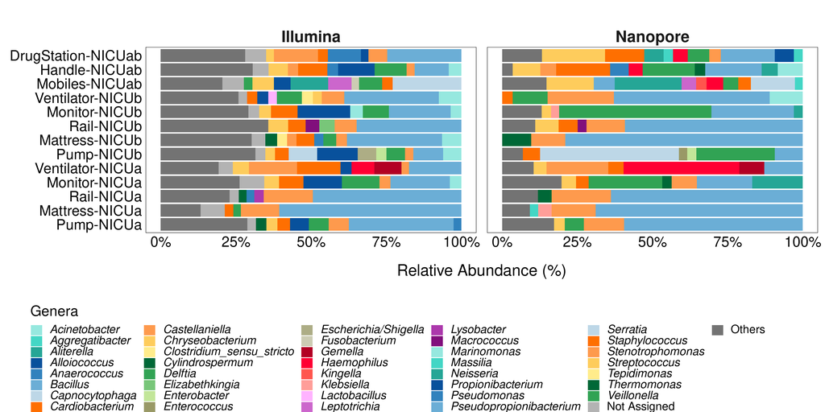

```r
ggplot( NICU_fulltable,
        aes( x = source, y = abundance, fill = NICU_order ) ) +
  geom_bar( stat = "identity", position = "fill" ) +
  coord_flip() +
  scale_fill_manual(values = mycolors_NICU_genera) +
  guides(fill = guide_legend(nrow = 8, title = "Genera")) +
  scale_y_continuous(labels = scales::percent) +
  scale_x_discrete(position = "bottom") +
  labs(y = "Relative Abundance (%)", x = "") +
  facet_wrap( ~ method ) +
  theme_minimal() +
  theme(
    # personalization of axis text
    axis.title.x = element_text(size = 22,color = "black", margin = margin(t = 20)),
    axis.text = element_text(size = 20, color = "black"),
    axis.text.y = element_text(angle = 0),
    axis.ticks = element_blank(),
    # personalization of the legend
    legend.title = element_text(size = 20 ),
    legend.text = element_markdown(size = 16),
    legend.key.height = unit(15, units = "pt"),
    legend.position = c(0.375, -0.675),
    # personalization of the panels
    panel.background = element_rect(fill = "white"),
    strip.background = element_rect(fill = "white", colour = "white"),
    strip.text.x = element_text(size = 22, face = "bold"),
    panel.spacing.x = unit(15, "pt"),
    panel.spacing.y = unit(10, "pt"),
    panel.grid.major = element_blank(),
    panel.grid.minor = element_blank(),
    # aspect ratio of the panel and margins of the plot
    plot.margin = margin(t = -150, r = 10, b = 0, l = 0),
    aspect.ratio = 9/16
)
```

### Permutational multivariate analysis of variance

The bar plot above allows us to better observe the general profile of the microbial community detected in the samples with bot sequencing methods, and given the overall results presented so far, we might assume that, even though we have different sequencing approaches, the overall microbial communities detected in the samples were not deeply affected. Nonetheless, we might employ a multivariate analysis to test whether there was a significant difference in the microbial composition in the samples due to the sequencing method.

In order to do so, we will start with the long data frames generated for the plotting (because of the way the data is already presented - for instance, with the “method column”), but we need to make some adjustments:

```r
table_minION <- minION_nicu_long %>%
  pivot_wider(names_from = taxa, values_from = abundance) %>%
  select(-Others)
table_illumina <- illumina_nicu_long %>%
  pivot_wider(names_from = taxa, values_from = abundance) %>%
  select(- Others, - `Not Assigned`)
all_data <- full_join(table_minION, table_illumina) %>% # this fills the gaps between the tables
  mutate_if(is.numeric, replace_na, 0)
head(all_data)[,1:5] # checking the first few rows and columns
```

```
## # A tibble: 6 x 5
##   source           method   Bacillus Castellaniella Delftia
##   <fct>            <chr>       <dbl>          <dbl>   <dbl>
## 1 Pump-NICUa       Nanopore   0.594          0.134   0.0636
## 2 Mattress-NICUa   Nanopore   0.689          0.146   0
## 3 Rail-NICUa       Nanopore   0.638          0.198   0
## 4 Monitor-NICUa    Nanopore   0.184          0.0840  0.244
## 5 Ventilator-NICUa Nanopore   0.128          0       0
## 6 Pump-NICUb       Nanopore   0.0935         0       0.260
```

Above, we have removed the information regarding the groups “Others” and “Not Assigned”, that are unimportant to us at the moment. Moreover, we joined the data frames using `full_join()`. This is important, because it will complete all of the missing genera from both approaches throughout the table. In the final table, the two first columns are metadata (which samples and sequencing method) and the remaining columns are the relative abundance values for the different genera.

To perform the PERMANOVA, we will calculate the Bray-Curtis dissimilarity index across all of our samples and input this new table into `adonis2()` from Vegan. In the `formula` parameter we specify which variable we aim for as the explanatory in our analysis. In the example below, it can be understood as “calculate all_data dataset in fucntion of the ‘method’ factor”

```r
set.seed(12345) # setting the random seed for reproducibility
all_data_dist <- vegdist(all_data[,-c(1,2)], "bray") # excludes the metadata columns
adonis2(formula = all_data_dist ~ method,
       data = all_data,
       permutations = 10000)
```

```
## Permutation test for adonis under reduced model
## Terms added sequentially (first to last)
## Permutation: free
## Number of permutations: 10000
##
## adonis2(formula = all_data_dist ~ method, data = all_data, permutations = 10000)
##          Df SumOfSqs      R2     F  Pr(>F)
## method    1   0.3907 0.07596 1.973 0.07089 .
## Residual 24   4.7527 0.92404
## Total    25   5.1434 1.00000
## ---
## Signif. codes:  0 '***' 0.001 '**' 0.01 '*' 0.05 '.' 0.1 ' ' 1
```

The results above show that, after 10000 permutations, the ‘method’ variable could explain only about 7.5% of the model (R²), and it did not find a significative correlation between the method employed and the differences of the microbiome (*p*-value = 0.07). Let’s compare this result to those we might obtain when analyzing data with regards to the environmental samples

```r
adonis2(formula = all_data_dist ~ source,
       data = all_data,
       permutations = 10000)
```

```
## Permutation test for adonis under reduced model
## Terms added sequentially (first to last)
## Permutation: free
## Number of permutations: 10000
##
## adonis2(formula = all_data_dist ~ source, data = all_data, permutations = 10000)
##          Df SumOfSqs      R2      F    Pr(>F)
## source   12   4.0115 0.77992 3.8392 9.999e-05 ***
## Residual 13   1.1319 0.22008
## Total    25   5.1434 1.00000
## ---
## Signif. codes:  0 '***' 0.001 '**' 0.01 '*' 0.05 '.' 0.1 ' ' 1
```

Here, we see that the results are extremely significative (***), and almost 78% of the variation in the model could be explained by this variable.